# Hacken_2023_GSE186137_bulkRNA-seq_analysis

Author

Pakorn Sagulkoo

In this code, we will analyse mouse bulk RNA-seq from [Hacken et al. (2023)](https://aacrjournals.org/bloodcancerdiscov/article/4/2/150/718388/In-Vivo-Modeling-of-CLL-Transformation-to-Richter). This study employed a mouse experimental model in which a CLL- and RT-like condition was induced using *del*(13q) *Cd19*-Cas9-GFP mice engrafted with LSK cells transduced with sgRNA-expressing lentivirus, followed by multiple loss-of-function alterations. After we performed Salmon converting FASTQ files to pseudocount data in each sample, we will convert them to a count matrix before we use the matrix for DESeq2 for further gene expression analysis.

## Import the relevant packages and set working path directory

```r
# Import the relavant packages
library(tximport)
library(ensembldb)
library(biomaRt)
library(dplyr)
library(tibble)
library(stringr)
library(ggplot2)
library(ggrepel)
library(DESeq2)
```

```r
# Check root path
here::here()
```

```
[1] "/mnt/hp-storage/users/pakorns"
```

## Define paths

```r
# Define paths to load and save files
path_to_samples <- here::here("RNAseq/Hacken_2023_GSE186137")
path_to_sample_metadata <- here::here("RNAseq/systematic_review/1-Hacken_2023_GSE186137/sample_metadata.csv")
path_to_ref_transcriptome <- "/home/pakorns/hc-storage/fastq_files/RNAseq/transcriptome_ref"
path_to_save_txi <- here::here("RNAseq/systematic_review/1-Hacken_2023_GSE186137/count_matrices/Hacken_txi.rds")
path_to_save_dea <- here::here("RNAseq/systematic_review/1-Hacken_2023_GSE186137/expression_data/Hacken_dea.rds")
path_to_save_hm_gsea <- here::here("RNAseq/systematic_review/1-Hacken_2023_GSE186137/enrichment_data/Hacken_hm_gsea.rds")
path_to_save_go_gsea <- here::here("RNAseq/systematic_review/1-Hacken_2023_GSE186137/enrichment_data/Hacken_go_gsea.rds")
```

## Load data and functions

```r
# Source functions
source(here::here("bin/utils.R"))
```

```r
# Load sample metadata
sample_metadata <- read.csv(path_to_sample_metadata)
DT::datatable(sample_metadata, options = list(scrollX = TRUE))
```

|  | SRA_RUN | GSM_ID | source_name | cell_type | condition_original | genotype | strain | tissue | condition |
| --- | --- | --- | --- | --- | --- | --- | --- | --- | --- |
| 1 | SRR16522866 | GSM5639186 | RS | Malignant B cells | RS | Multi-plex LOF | C57BL/6 | Spleen | RT |
| 2 | SRR16522867 | GSM5639187 | RS | Malignant B cells | RS | Multi-plex LOF | C57BL/6 | Spleen | RT |
| 3 | SRR16522868 | GSM5639188 | RS | Malignant B cells | RS | Multi-plex LOF | C57BL/6 | Spleen | RT |
| 4 | SRR16522869 | GSM5639189 | RS | Malignant B cells | RS | Multi-plex LOF | C57BL/6 | Spleen | RT |
| 5 | SRR16522870 | GSM5639190 | RS | Malignant B cells | RS | Multi-plex LOF | C57BL/6 | Spleen | RT |
| 6 | SRR16522871 | GSM5639191 | RS | Malignant B cells | RS | Multi-plex LOF | C57BL/6 | Spleen | RT |
| 7 | SRR16522872 | GSM5639192 | RS | Malignant B cells | RS | Multi-plex LOF | C57BL/6 | Spleen | RT |
| 8 | SRR16522873 | GSM5639193 | RS | Malignant B cells | RS | Multi-plex LOF | C57BL/6 | Spleen | RT |
| 9 | SRR16522874 | GSM5639194 | RS | Malignant B cells | RS | Multi-plex LOF | C57BL/6 | Spleen | RT |
| 10 | SRR16522875 | GSM5639195 | RS | Malignant B cells | RS | Multi-plex LOF | C57BL/6 | Spleen | RT |

[output cut: 14 more lines]

```r
# Create a vector collecting Salmon quant.sf path in each sample
path_to_download <- str_c(path_to_samples, "/", sample_metadata$SRA_RUN, "/quant.sf")
names(path_to_download) <- sample_metadata$SRA_RUN
path_to_download
```

```
                                                                      SRR16522866
"/mnt/hp-storage/users/pakorns/RNAseq/Hacken_2023_GSE186137/SRR16522866/quant.sf"
                                                                      SRR16522867
"/mnt/hp-storage/users/pakorns/RNAseq/Hacken_2023_GSE186137/SRR16522867/quant.sf"
                                                                      SRR16522868
"/mnt/hp-storage/users/pakorns/RNAseq/Hacken_2023_GSE186137/SRR16522868/quant.sf"
                                                                      SRR16522869
"/mnt/hp-storage/users/pakorns/RNAseq/Hacken_2023_GSE186137/SRR16522869/quant.sf"
                                                                      SRR16522870
"/mnt/hp-storage/users/pakorns/RNAseq/Hacken_2023_GSE186137/SRR16522870/quant.sf"
                                                                      SRR16522871
"/mnt/hp-storage/users/pakorns/RNAseq/Hacken_2023_GSE186137/SRR16522871/quant.sf"
                                                                      SRR16522872
"/mnt/hp-storage/users/pakorns/RNAseq/Hacken_2023_GSE186137/SRR16522872/quant.sf"
                                                                      SRR16522873
"/mnt/hp-storage/users/pakorns/RNAseq/Hacken_2023_GSE186137/SRR16522873/quant.sf"
                                                                      SRR16522874
"/mnt/hp-storage/users/pakorns/RNAseq/Hacken_2023_GSE186137/SRR16522874/quant.sf"
                                                                      SRR16522875
"/mnt/hp-storage/users/pakorns/RNAseq/Hacken_2023_GSE186137/SRR16522875/quant.sf"
                                                                      SRR16522876
"/mnt/hp-storage/users/pakorns/RNAseq/Hacken_2023_GSE186137/SRR16522876/quant.sf"
                                                                      SRR16522881
"/mnt/hp-storage/users/pakorns/RNAseq/Hacken_2023_GSE186137/SRR16522881/quant.sf"
                                                                      SRR16522882
"/mnt/hp-storage/users/pakorns/RNAseq/Hacken_2023_GSE186137/SRR16522882/quant.sf"
                                                                      SRR16522883
"/mnt/hp-storage/users/pakorns/RNAseq/Hacken_2023_GSE186137/SRR16522883/quant.sf"
                                                                      SRR16522884
"/mnt/hp-storage/users/pakorns/RNAseq/Hacken_2023_GSE186137/SRR16522884/quant.sf"
                                                                      SRR16522885
"/mnt/hp-storage/users/pakorns/RNAseq/Hacken_2023_GSE186137/SRR16522885/quant.sf"
                                                                      SRR16522886
"/mnt/hp-storage/users/pakorns/RNAseq/Hacken_2023_GSE186137/SRR16522886/quant.sf"
                                                                      SRR16522887
"/mnt/hp-storage/users/pakorns/RNAseq/Hacken_2023_GSE186137/SRR16522887/quant.sf"
                                                                      SRR16522888
"/mnt/hp-storage/users/pakorns/RNAseq/Hacken_2023_GSE186137/SRR16522888/quant.sf"
                                                                      SRR16522889
"/mnt/hp-storage/users/pakorns/RNAseq/Hacken_2023_GSE186137/SRR16522889/quant.sf"
                                                                      SRR16522890
"/mnt/hp-storage/users/pakorns/RNAseq/Hacken_2023_GSE186137/SRR16522890/quant.sf"
                                                                      SRR16522891
"/mnt/hp-storage/users/pakorns/RNAseq/Hacken_2023_GSE186137/SRR16522891/quant.sf"
                                                                      SRR16522892
"/mnt/hp-storage/users/pakorns/RNAseq/Hacken_2023_GSE186137/SRR16522892/quant.sf"
                                                                      SRR16522893
"/mnt/hp-storage/users/pakorns/RNAseq/Hacken_2023_GSE186137/SRR16522893/quant.sf"
```

## Convert salmon pseudocounts to an expression matrix

```r
# Load the ensembl mm39 gtf file
path_to_mm39_transcriptome <- str_c(path_to_ref_transcriptome, "/Mus_musculus.GRCm39.115.gtf.gz")
edb <- ensDbFromGtf(path_to_mm39_transcriptome) # Return edb = "./Mus_musculus.GRCm39.115.sqlite"
```

```r
# Make the transcript-to-gene map (tx2gene)
edb <- "./Mus_musculus.GRCm39.115.sqlite"
edb_obj <- EnsDb(edb)
tx2gene <- transcripts(edb_obj,
                       columns = c("tx_id","gene_id","gene_name"),
                       return.type="DataFrame")

# convert to a plain data.frame for tximport
tx2gene <- as.data.frame(tx2gene)
head(tx2gene)
```

```
               tx_id            gene_id gene_name
1 ENSMUST00000000001 ENSMUSG00000000001     Gnai3
2 ENSMUST00000000003 ENSMUSG00000000003      Pbsn
3 ENSMUST00000000010 ENSMUSG00000020875     Hoxb9
4 ENSMUST00000000028 ENSMUSG00000000028     Cdc45
5 ENSMUST00000000033 ENSMUSG00000048583      Igf2
6 ENSMUST00000000049 ENSMUSG00000000049      Apoh
```

```r
# Load pseudocount files
txi <- tximport(path_to_download,
                type = "salmon",
                tx2gene = tx2gene,
                ignoreTxVersion = TRUE
               )

# This gives you txi$counts, txi$abundance (TPM), txi$length
head(txi$counts)
```

```
                   SRR16522866 SRR16522867 SRR16522868 SRR16522869 SRR16522870
ENSMUSG00000000001    9250.443    5801.456    10845.14    5628.978    7731.582
ENSMUSG00000000003       0.000       0.000        0.00       0.000       0.000
ENSMUSG00000000028    1655.838     871.272     2216.81     763.553    1560.548
ENSMUSG00000000037       0.000       0.000        0.00       3.000       0.000
ENSMUSG00000000049       0.000       3.000        0.00       5.000       0.000
ENSMUSG00000000056    1381.008     726.000     2435.00    2960.565    5211.123
                   SRR16522871 SRR16522872 SRR16522873 SRR16522874 SRR16522875
ENSMUSG00000000001    8858.588   11644.619   17756.790    7681.064    6190.535
ENSMUSG00000000003       0.000       0.000       0.000       1.000       0.000
ENSMUSG00000000028    2348.450    2398.764    2038.099    6645.837    1238.351
ENSMUSG00000000037       3.000      38.000     191.000       0.000       0.000
ENSMUSG00000000049      34.000      12.000     128.000       2.000       0.000
ENSMUSG00000000056    2712.891    2434.923    2282.985    4365.720    2323.326
                   SRR16522876 SRR16522881 SRR16522882 SRR16522883 SRR16522884
ENSMUSG00000000001   10006.341    7955.158    7707.247    7003.805    7956.562
ENSMUSG00000000003       0.000       0.000       0.000       0.000       4.000
ENSMUSG00000000028     755.218     363.460     352.146     240.014     298.614
ENSMUSG00000000037       0.000       0.000       0.000       3.000      15.000
ENSMUSG00000000049       0.000       0.000       0.000       3.094       0.000
ENSMUSG00000000056     926.000    3169.128    4417.693    4370.852    3964.705
                   SRR16522885 SRR16522886 SRR16522887 SRR16522888 SRR16522889
ENSMUSG00000000001   11133.422    5105.565    7174.646   12176.968    4584.059
ENSMUSG00000000003       0.000       0.000       0.000       0.000       0.000
ENSMUSG00000000028     749.937    2103.809     952.595    1621.185     329.373
ENSMUSG00000000037       8.000       0.000       2.000       9.000       0.000
ENSMUSG00000000049       0.000       1.000       1.000       9.000       0.000
ENSMUSG00000000056    4306.948    1861.569    3009.220    3302.715    1973.206
                   SRR16522890 SRR16522891 SRR16522892 SRR16522893
ENSMUSG00000000001    9069.502   11148.181    6841.055    9062.222
ENSMUSG00000000003       0.000       0.000       0.000       0.000
ENSMUSG00000000028    1656.773     930.597     632.539     208.558
ENSMUSG00000000037       0.000       0.000       0.000       0.000
ENSMUSG00000000049      15.000      36.000       3.000       1.000
ENSMUSG00000000056    2841.215    3648.088    1919.217    1456.203
```

```r
# Save the expression file
saveRDS(txi, path_to_save_txi)
```

## Transcriptomics analysis using DESeq2

```r
# Import the relevant package
library(DESeq2)
library(sva)
library(limma)
```

### Create a DESeq2 object

```r
# Create metadata for DESeq2 object
colData <- sample_metadata[, c("SRA_RUN", "condition")] %>%
  rename(samples = "SRA_RUN")
colData$group <- ifelse(colData$condition == "RT", "RT", "Others")
rownames(colData) <- colData$samples
colData$condition <- factor(colData$condition)
DT::datatable(colData, options = list(scrollX = TRUE))
```

|  | samples | condition | group |
| --- | --- | --- | --- |
| SRR16522866 | SRR16522866 | RT | RT |
| SRR16522867 | SRR16522867 | RT | RT |
| SRR16522868 | SRR16522868 | RT | RT |
| SRR16522869 | SRR16522869 | RT | RT |
| SRR16522870 | SRR16522870 | RT | RT |
| SRR16522871 | SRR16522871 | RT | RT |
| SRR16522872 | SRR16522872 | RT | RT |
| SRR16522873 | SRR16522873 | RT | RT |
| SRR16522874 | SRR16522874 | RT | RT |
| SRR16522875 | SRR16522875 | RT | RT |

[output cut: 14 more lines]

```r
# Create the object
dds <- DESeqDataSetFromTximport(txi, colData, ~ condition)
```

```r
# Keep genes with at least 10 counts across all samples
keep <- rowSums(counts(dds)) >= 10
dds <- dds[keep,]

# Run DESeq2
dds$condition <- relevel(dds$condition, ref = "CTRL")
dds <- DESeq(dds)
```

### Plot the PCA based on the expression data

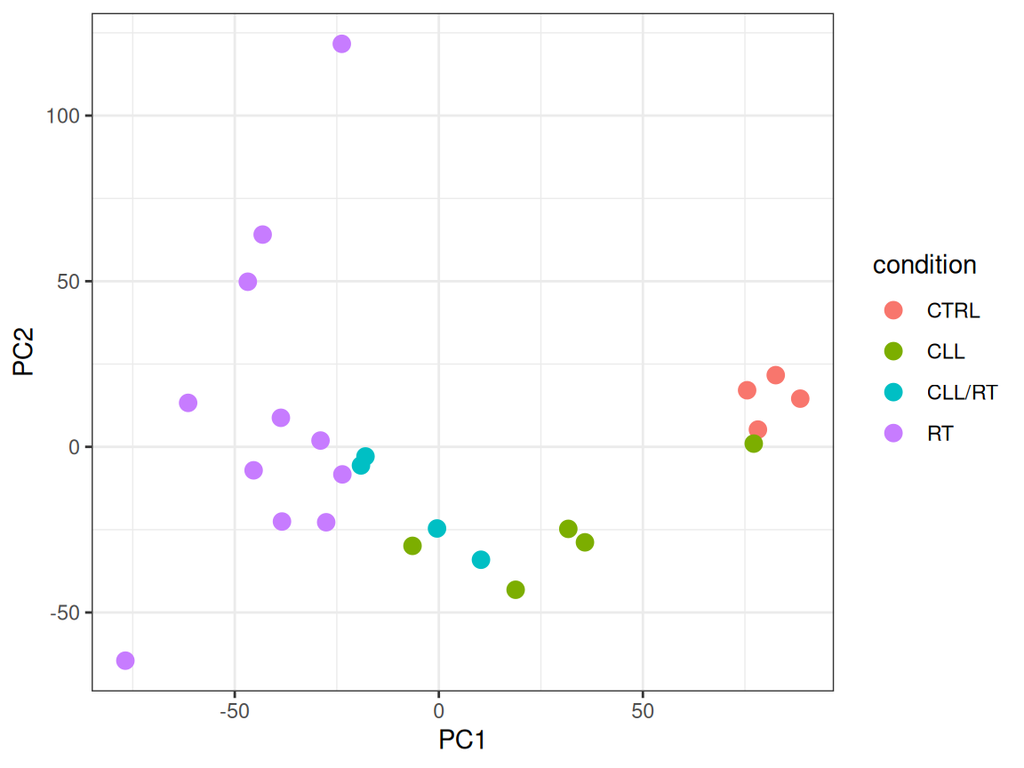

```r
# Variance stabilised transformation
vsdata <- DESeq2::vst(dds, blind = FALSE)

# Extract matrix
vs_mat <- assay(vsdata)

# Adjust for batch (assume batch info is in colData(dds)$batch)
vs_mat_corrected <- removeBatchEffect(vs_mat, batch = colData(dds)$batch)

# PCA on corrected data
pca <- prcomp(t(vs_mat_corrected))

# Make a dataframe for ggplot
pca_df <- data.frame(pca$x,
                     condition = colData(dds)$condition,
                     sample = rownames(colData(dds)))

# Plot
ggplot(pca_df, aes(PC1, PC2, color = condition)) +
  geom_point(size = 3) +
  theme_bw()
```

From the PCA plot we can see that each sample is grouped based on condition although samples in CLL/RS group distribute between RT and CLL groups, consistent with their mixing phenotypes.

### Convert mouse to human ensemble ids

```r
# Get orthologs
path_to_ortholog <- str_c(path_to_ref_transcriptome, "/mouse_human_ortholog.txt")
orthologs <- read.csv(path_to_ortholog)
head(orthologs)
```

```
   Gene.stable.ID Gene.stable.ID.version Mouse.gene.stable.ID Mouse.gene.name
1 ENSG00000198888      ENSG00000198888.2   ENSMUSG00000064341          mt-Nd1
2 ENSG00000198763      ENSG00000198763.3   ENSMUSG00000064345          mt-Nd2
3 ENSG00000198804      ENSG00000198804.2   ENSMUSG00000064351          mt-Co1
4 ENSG00000198712      ENSG00000198712.1   ENSMUSG00000064354          mt-Co2
5 ENSG00000228253      ENSG00000228253.1   ENSMUSG00000064356         mt-Atp8
6 ENSG00000198899      ENSG00000198899.2   ENSMUSG00000064357         mt-Atp6
  Gene.name
1    MT-ND1
2    MT-ND2
3    MT-CO1
4    MT-CO2
5   MT-ATP8
6   MT-ATP6
```

### RT vs CLL

```r
# Generate a table for gene expression
res_RT_vs_CLL <- lfcShrink(dds, contrast = c("condition", "RT", "CLL"), type = "normal")
head(res_RT_vs_CLL)
```

[output not shown]

```r
# Use left_join to convert mouse to human ensembl ids
human_res_RT_vs_CLL <- as.data.frame(res_RT_vs_CLL) %>%
  rownames_to_column("Mouse_Ensembl_ID") %>%
  left_join(orthologs, by = c("Mouse_Ensembl_ID" = "Mouse.gene.stable.ID"))
```

```r
# Save the expression result
saveRDS(human_res_RT_vs_CLL, path_to_save_dea)
```

### RT vs others

```r
# Create the object and colData based on group (RT and others) instead of condition
dds <- DESeqDataSetFromTximport(txi, colData, ~ group)

# Keep genes with at least 10 counts across all samples
keep <- rowSums(counts(dds)) >= 10
dds <- dds[keep,]

# Run DESeq2
dds$condition <- relevel(dds$group, ref = "Others")
dds <- DESeq(dds)
```

```r
# Generate a table for gene expression
res_RT_vs_others <- lfcShrink(dds, contrast = c("group", "RT", "Others"), type = "normal")
head(res_RT_vs_others)
```

```
log2 fold change (MAP): group RT vs Others
Wald test p-value: group RT vs Others
DataFrame with 6 rows and 6 columns
                     baseMean log2FoldChange     lfcSE      stat      pvalue
                    <numeric>      <numeric> <numeric> <numeric>   <numeric>
ENSMUSG00000000001 8927.25524       0.416382  0.229528  1.814083 0.069664948
ENSMUSG00000000028 1344.78201       1.316035  0.382688  3.438632 0.000584662
ENSMUSG00000000037    3.31962       1.373905  0.888466  0.423889 0.671646656
ENSMUSG00000000049    6.52446       0.497428  0.822826  0.604817 0.545300824
ENSMUSG00000000056 2758.08763      -0.361717  0.236452 -1.529770 0.126073587
ENSMUSG00000000058    7.25955       1.491305  0.836076 -2.362442 0.018154997
                         padj
                    <numeric>
ENSMUSG00000000001 0.19832840
ENSMUSG00000000028 0.00731939
ENSMUSG00000000037 0.81517480
ENSMUSG00000000049 0.72355844
ENSMUSG00000000056 0.29153656
ENSMUSG00000000058 0.08109411
```

```r
# Use left_join to convert mouse to human ensembl ids
human_res_RT_vs_others <- as.data.frame(res_RT_vs_others) %>%
  rownames_to_column("Mouse_Ensembl_ID") %>%
  left_join(orthologs, by = c("Mouse_Ensembl_ID" = "Mouse.gene.stable.ID"))
head(human_res_RT_vs_others)
```

```
    Mouse_Ensembl_ID    baseMean log2FoldChange     lfcSE       stat
1 ENSMUSG00000000001 8927.255240      0.4163824 0.2295275  1.8140830
2 ENSMUSG00000000028 1344.782005      1.3160349 0.3826878  3.4386315
3 ENSMUSG00000000037    3.319620      1.3739047 0.8884663  0.4238892
4 ENSMUSG00000000049    6.524457      0.4974278 0.8228264  0.6048167
5 ENSMUSG00000000056 2758.087625     -0.3617167 0.2364520 -1.5297703
6 ENSMUSG00000000058    7.259547      1.4913045 0.8360762 -2.3624417
        pvalue        padj  Gene.stable.ID Gene.stable.ID.version
1 0.0696649480 0.198328401 ENSG00000065135     ENSG00000065135.13
2 0.0005846624 0.007319388 ENSG00000093009     ENSG00000093009.12
3 0.6716466556 0.815174800 ENSG00000102098     ENSG00000102098.20
4 0.5453008244 0.723558444 ENSG00000091583     ENSG00000091583.12
5 0.1260735874 0.291536563 ENSG00000141562     ENSG00000141562.20
6 0.0181549973 0.081094109 ENSG00000105971     ENSG00000105971.16
  Mouse.gene.name Gene.name
1           Gnai3     GNAI3
2           Cdc45     CDC45
3           Scml2     SCML2
4            Apoh      APOH
5            Narf      NARF
6            Cav2      CAV2
```

#### Plot a heatmap of gene expression

```r
# Import the relevant package
library(pheatmap)
library(RColorBrewer)
```

```r
# Data transformation
vsd <- DESeq2::vst(dds, blind=FALSE)       # Variance-stabilizing transformation
#rld <- rlog(dds_filtered, blind=FALSE)      # Regularized log transformation

# Extract transformed expression matrix
expr_mat <- assay(vsd)

# Calculate z-scores
zscore_mat <- t(scale(t(expr_mat)))
```

```r
# Define samples in each condition
CTRL_sample <- colData$samples[colData$condition == "CTRL"]
CLL_sample <- colData$samples[colData$condition == "CLL"]
CLL_RT_sample <- colData$samples[colData$condition == "CLL/RT"]
RT_sample <- colData$samples[colData$condition == "RT"]
```

```r
# Extract phenotypes info from column names
conditions <-  ifelse(colnames(zscore_mat) %in% CTRL_sample, "CTRL",
                      ifelse(colnames(zscore_mat) %in% CLL_sample, "CLL",
                             ifelse(colnames(zscore_mat) %in% CLL_RT_sample, "CLL/RT", "RT")))

# Create annotation dataframe
annotation_col <- data.frame(
  Condition = factor(conditions, levels = c("CTRL", "CLL", "CLL/RT", "RT"))
)
annotation_col <- annotation_col[, "Condition", drop = FALSE]  # keep as data frame
rownames(annotation_col) <- colnames(zscore_mat)

# Order by Condition and then Case
order_cols <- order(annotation_col$Condition)
zscore_mat_ordered <- zscore_mat[, order_cols]
annotation_col_ordered <- annotation_col[order_cols, , drop = FALSE]
```

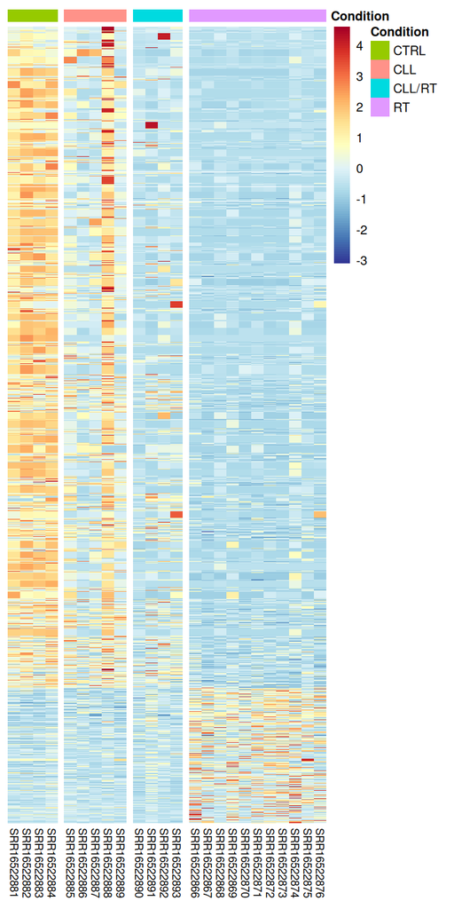

```r
# Filter for significant DE genes
sig_genes <- human_res_RT_vs_others[!is.na(human_res_RT_vs_others$padj) & human_res_RT_vs_others$padj < 0.05 & abs(human_res_RT_vs_others$log2FoldChange) > 2, ]

# Order genes by log2FoldChange (descending: up -> down)
gene_order <- sig_genes$Mouse_Ensembl_ID[order(sig_genes$log2FoldChange, decreasing = FALSE)]

# Subset zscore matrix
zscore_mat_sig <- zscore_mat_ordered[gene_order, ]

# Plot heatmap
pheatmap(
  zscore_mat_sig,
  cluster_rows = FALSE,
  cluster_cols = FALSE,
  show_rownames = FALSE,
  color = colorRampPalette(rev(brewer.pal(11, "RdYlBu")))(100),
  annotation_col = annotation_col_ordered,
  fontsize = 8,
  fontsize_row = 7,
  fontsize_col = 7,
  gaps_col = which(diff(as.numeric(factor(annotation_col_ordered$Condition))) != 0)
)
```

## Gene Set Enrichment Analysis (GSEA)

```r
# Import the related libraries in functional enrichment analysis
library(clusterProfiler)
library(enrichplot)
library(msigdbr)
library(org.Hs.eg.db)
```

### RT vs CLL

```r
# Manipulate the expression data
dea <- human_res_RT_vs_CLL[!is.na(human_res_RT_vs_CLL$Gene.stable.ID), ]
lfc_vector <- dea$log2FoldChange # Create a named vector ranked based on the log2 fold change
names(lfc_vector) <- dea$Gene.stable.ID
lfc_vector <- na.omit(lfc_vector) # Omit any NA values
lfc_vector <- sort(lfc_vector, decreasing = TRUE) # Sort the log2 fold change in descending order
lfc_vector <- lfc_vector[!duplicated(names(lfc_vector))]
```

#### Hallmark

```r
# Hallmark
HM_gsea <- HM_GSEA(lfc_vector, gene_ident = "ensembl_gene")

# Collect the HM GSEA result
HM_GSEA.result <- HM_gsea@result
HM_GSEA_selected.result <- HM_GSEA.result %>%
  as_tibble() %>%
  dplyr::select(c(Description, NES, pvalue, p.adjust))

DT::datatable(HM_GSEA_selected.result, options = list(scrollX = TRUE))
```

|  | Description | NES | pvalue | p.adjust |
| --- | --- | --- | --- | --- |
| 1 | HALLMARK_E2F_TARGETS | 2.470652711507856 | 1.794802429575943e-17 | 8.974012147879713e-16 |
| 2 | HALLMARK_INFLAMMATORY_RESPONSE | -2.410944717863329 | 1.85119361247944e-15 | 4.627984031198601e-14 |
| 3 | HALLMARK_INTERFERON_GAMMA_RESPONSE | -2.345399185526173 | 4.482928561301436e-14 | 7.47154760216906e-13 |
| 4 | HALLMARK_MYC_TARGETS_V1 | 2.245376748493395 | 4.161866104849956e-13 | 5.202332631062445e-12 |
| 5 | HALLMARK_G2M_CHECKPOINT | 2.25809167780335 | 1.953507708167544e-12 | 1.953507708167544e-11 |
| 6 | HALLMARK_ALLOGRAFT_REJECTION | -1.98489875013897 | 6.96080979304635e-08 | 5.800674827538626e-07 |
| 7 | HALLMARK_IL6_JAK_STAT3_SIGNALING | -2.179893045576369 | 1.960462500567809e-07 | 1.400330357548435e-06 |
| 8 | HALLMARK_COMPLEMENT | -1.860962047187929 | 8.259720116712413e-07 | 5.162325072945258e-06 |
| 9 | HALLMARK_EPITHELIAL_MESENCHYMAL_TRANSITION | -1.825348047745785 | 2.224837662771406e-06 | 1.236020923761892e-05 |
| 10 | HALLMARK_INTERFERON_ALPHA_RESPONSE | -1.935934924939785 | 2.023178728159758e-05 | 0.0001011589364079879 |

[output cut: 12 more lines]

We will explore the trends of hallmark terms reported from other single-cell pseudobulk studies such as Nadeu et al. (2022) and Hing et al (2023). From those studies, the terms such as E2F targets, Myc targets, and oxidative phosphorylation (OXPHOS) were upregulated.

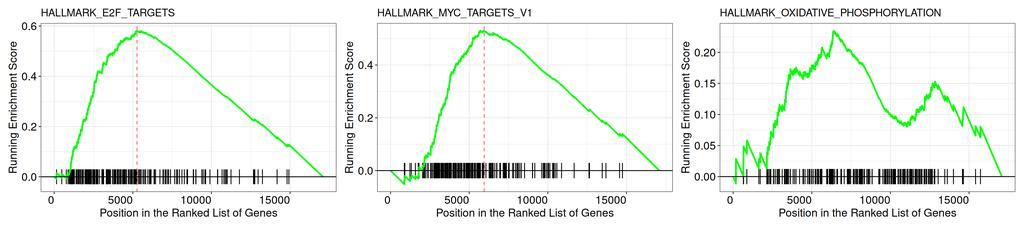

```r
# GSEA plot for HALLMARK_E2F_TARGETS, HALLMARK_MYC_TARGETS_V1, and HALLMARK_OXIDATIVE_PHOSPHORYLATION

E2F_gsea.plt <- gseaplot(HM_gsea,
                          by = "runningScore",
                          title = "HALLMARK_E2F_TARGETS",
                          geneSetID = "HALLMARK_E2F_TARGETS",
                          base_size = 10) +
  theme(axis.text.x = element_text(angle = 0, hjust = 1))

Myc_gsea.plt <- gseaplot(HM_gsea,
                          by = "runningScore",
                          title = "HALLMARK_MYC_TARGETS_V1",
                          geneSetID = "HALLMARK_MYC_TARGETS_V1",
                          base_size = 10) +
  theme(axis.text.x = element_text(angle = 0, hjust = 1))

OXPHOS_gsea.plt <- gseaplot(HM_gsea,
                          by = "runningScore",
                          title = "HALLMARK_OXIDATIVE_PHOSPHORYLATION",
                          geneSetID = "HALLMARK_OXIDATIVE_PHOSPHORYLATION",
                          base_size = 10) +
  theme(axis.text.x = element_text(angle = 0, hjust = 1))

E2F_gsea.plt + Myc_gsea.plt + OXPHOS_gsea.plt
```

#### GO:BP

```r
# GO:BP
GOBP_gsea <- GO_GSEA(lfc_vector, gene_ident = "ensembl_gene")

# Collect the GSEA result
GOBP_GSEA.result <- GOBP_gsea@result
GOBP_GSEA_selected.result <- GOBP_GSEA.result %>%
  as_tibble() %>%
  dplyr::select(c(Description, NES, pvalue, p.adjust))

DT::datatable(GOBP_GSEA_selected.result, options = list(scrollX = TRUE))
```

|  | Description | NES | pvalue | p.adjust |
| --- | --- | --- | --- | --- |
| 1 | GOBP_REGULATION_OF_INFLAMMATORY_RESPONSE | -2.30205355790461 | 6.697463292738013e-19 | 1.963696237430785e-15 |
| 2 | GOBP_LEUKOCYTE_MIGRATION | -2.229739507041426 | 4.84143663861639e-17 | 7.097546112211628e-14 |
| 3 | GOBP_DEFENSE_RESPONSE_TO_BACTERIUM | -2.374900910077255 | 3.089290889023739e-16 | 1.811560177323521e-13 |
| 4 | GOBP_CYTOKINE_MEDIATED_SIGNALING_PATHWAY | -2.111502377839353 | 2.653347801904302e-16 | 1.811560177323521e-13 |
| 5 | GOBP_IMMUNE_RESPONSE_REGULATING_SIGNALING_PATHWAY | -2.08341215577799 | 1.910752554371325e-16 | 1.811560177323521e-13 |
| 6 | GOBP_MYELOID_LEUKOCYTE_MIGRATION | -2.410498733694955 | 8.647044834962939e-16 | 4.225522576018556e-13 |
| 7 | GOBP_MYELOID_LEUKOCYTE_ACTIVATION | -2.342856510345548 | 1.055583526665883e-15 | 4.421387000263384e-13 |
| 8 | GOBP_POSITIVE_REGULATION_OF_CYTOKINE_PRODUCTION | -2.064713152760569 | 2.730426629782008e-15 | 1.000701359815106e-12 |
| 9 | GOBP_TAXIS | -2.099869285964766 | 3.090557469437021e-15 | 1.006834944487705e-12 |
| 10 | GOBP_IMMUNE_RESPONSE_REGULATING_CELL_SURFACE_RECEPTOR_SIGNALING_PATHWAY | -2.223687035779505 | 1.398975544032207e-14 | 4.101796295102432e-12 |

[output cut: 608 more lines]

We will also explore the trends of GO:BP terms reported from other single-cell studies such as Nadeu et al. (2022) and Hing et al (2023). From those studies, the terms such as OXPHOS and mitochondrial translation were upregulated while BCR signalling was downregulated.

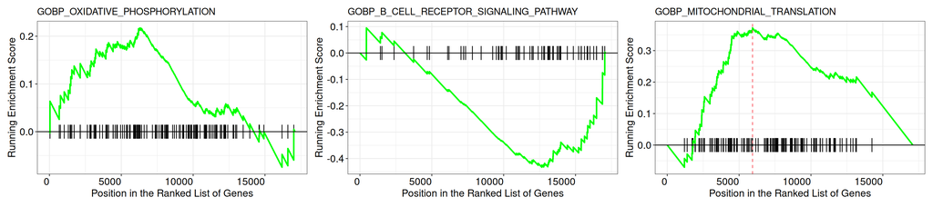

```r
# GSEA plot for GOBP_OXIDATIVE_PHOSPHORYLATION, GOBP_B_CELL_RECEPTOR_SIGNALING_PATHWAY, and GOBP_MITOCHONDRIAL_TRANSLATION

OXPHOS_GO_gsea.plt <- gseaplot(GOBP_gsea,
                          by = "runningScore",
                          title = "GOBP_OXIDATIVE_PHOSPHORYLATION",
                          geneSetID = "GOBP_OXIDATIVE_PHOSPHORYLATION",
                          base_size = 10) +
  theme(axis.text.x = element_text(angle = 0, hjust = 1))

BCR_GO_gsea.plt <- gseaplot(GOBP_gsea,
                          by = "runningScore",
                          title = "GOBP_B_CELL_RECEPTOR_SIGNALING_PATHWAY",
                          geneSetID = "GOBP_B_CELL_RECEPTOR_SIGNALING_PATHWAY",
                          base_size = 10) +
  theme(axis.text.x = element_text(angle = 0, hjust = 1))

mitochondrial_GO_gsea.plt <- gseaplot(GOBP_gsea,
                          by = "runningScore",
                          title = "GOBP_MITOCHONDRIAL_TRANSLATION",
                          geneSetID = "GOBP_MITOCHONDRIAL_TRANSLATION",
                          base_size = 10) +
  theme(axis.text.x = element_text(angle = 0, hjust = 1))

OXPHOS_GO_gsea.plt + BCR_GO_gsea.plt + mitochondrial_GO_gsea.plt
```

```r
# Save gene expression and GSEA data
saveRDS(HM_gsea, path_to_save_hm_gsea)
saveRDS(GOBP_gsea, path_to_save_go_gsea)
```

### RT vs others

```r
# Manipulate the expression data
dea <- human_res_RT_vs_others[!is.na(human_res_RT_vs_others$Gene.stable.ID), ]
lfc_vector <- dea$log2FoldChange # Create a named vector ranked based on the log2 fold change
names(lfc_vector) <- dea$Gene.stable.ID
lfc_vector <- na.omit(lfc_vector) # Omit any NA values
lfc_vector <- sort(lfc_vector, decreasing = TRUE) # Sort the log2 fold change in descending order
lfc_vector <- lfc_vector[!duplicated(names(lfc_vector))]
```

```r
# Hallmark
HM_gsea <- HM_GSEA(lfc_vector, gene_ident = "ensembl_gene")

# Collect the HM GSEA result
HM_GSEA.result <- HM_gsea@result
HM_GSEA_selected.result <- HM_GSEA.result %>%
  as_tibble() %>%
  dplyr::select(c(Description, NES, pvalue, p.adjust))

DT::datatable(HM_GSEA_selected.result, options = list(scrollX = TRUE))
```

|  | Description | NES | pvalue | p.adjust |
| --- | --- | --- | --- | --- |
| 1 | HALLMARK_E2F_TARGETS | 3.005121676287738 | 2.830882078081771e-32 | 1.415441039040885e-30 |
| 2 | HALLMARK_MYC_TARGETS_V1 | 2.760846698350929 | 2.055337762828922e-23 | 5.138344407072305e-22 |
| 3 | HALLMARK_G2M_CHECKPOINT | 2.682832239594969 | 5.899663155503275e-21 | 9.832771925838793e-20 |
| 4 | HALLMARK_INFLAMMATORY_RESPONSE | -2.427686737234809 | 1.325761362748035e-16 | 1.657201703435043e-15 |
| 5 | HALLMARK_INTERFERON_GAMMA_RESPONSE | -2.30589115938306 | 2.012559063580841e-13 | 2.012559063580841e-12 |
| 6 | HALLMARK_ALLOGRAFT_REJECTION | -2.175006417814646 | 5.643169613828091e-11 | 4.702641344856743e-10 |
| 7 | HALLMARK_MYC_TARGETS_V2 | 2.395443031475907 | 4.187321770303744e-09 | 2.990944121645532e-08 |
| 8 | HALLMARK_EPITHELIAL_MESENCHYMAL_TRANSITION | -1.974560221530081 | 4.121287180393816e-08 | 2.575804487746135e-07 |
| 9 | HALLMARK_COMPLEMENT | -1.961764931332451 | 2.518950764871292e-07 | 1.399417091595162e-06 |
| 10 | HALLMARK_IL6_JAK_STAT3_SIGNALING | -2.124522569725452 | 4.206825954879395e-07 | 2.103412977439698e-06 |

[output cut: 15 more lines]

From the enrichment results we found that significantly upregulated hallmark terms, such as E2F targets, Myc targets, and G2M checkpoint, were consistent with the original results in Figure 4B. In addition, significantly downregulated terms, such as IFN-gamma response and IL6-JAK-STAT signalling, were also consistent although no IL2-STAT5 signalling was detected. Interestingly, we found OXPHOS was significantly upregulated between RT and others while the term was not significant when comparing only RT and CLL conditions.